# Assignment - 02

Umme Atiqua Jahin

2025-09-28

## Introduction

This report implements and compares three classical classification methods — Linear Discriminant Analysis (LDA), Quadratic Discriminant Analysis (QDA), and Logistic Regression — to predict malignancy in the Breast Cancer Wisconsin (Diagnostic) dataset. We perform exploratory data analysis (EDA), preprocessing, model fitting, evaluation (accuracy, precision, recall, F1), and discuss trade-offs and results.

## Data Preprocessing

Loading Necessary library

```r
library(tidyverse)
library(dplyr)
library(MASS)
library(mlbench)
```

Loading Dataset

```r
data("BreastCancer")
head(BreastCancer)
```

```
##        Id Cl.thickness Cell.size Cell.shape Marg.adhesion Epith.c.size
## 1 1000025            5         1          1             1            2
## 2 1002945            5         4          4             5            7
## 3 1015425            3         1          1             1            2
## 4 1016277            6         8          8             1            3
## 5 1017023            4         1          1             3            2
## 6 1017122            8        10         10             8            7
##   Bare.nuclei Bl.cromatin Normal.nucleoli Mitoses     Class
## 1           1           3               1       1    benign
## 2          10           3               2       1    benign
## 3           2           3               1       1    benign
## 4           4           3               7       1    benign
## 5           1           3               1       1    benign
## 6          10           9               7       1 malignant
```

Structure of Dataset and summary statistics

```r
names(BreastCancer)
```

```
##  [1] "Id"              "Cl.thickness"    "Cell.size"       "Cell.shape"
##  [5] "Marg.adhesion"   "Epith.c.size"    "Bare.nuclei"     "Bl.cromatin"
##  [9] "Normal.nucleoli" "Mitoses"         "Class"
```

```r
dim(BreastCancer)
```

```
## [1] 699  11
```

```r
str(BreastCancer)
```

```
## 'data.frame':    699 obs. of  11 variables:
##  $ Id             : chr  "1000025" "1002945" "1015425" "1016277" ...
##  $ Cl.thickness   : Ord.factor w/ 10 levels "1"<"2"<"3"<"4"<..: 5 5 3 6 4 8 1 2 2 4 ...
##  $ Cell.size      : Ord.factor w/ 10 levels "1"<"2"<"3"<"4"<..: 1 4 1 8 1 10 1 1 1 2 ...
##  $ Cell.shape     : Ord.factor w/ 10 levels "1"<"2"<"3"<"4"<..: 1 4 1 8 1 10 1 2 1 1 ...
##  $ Marg.adhesion  : Ord.factor w/ 10 levels "1"<"2"<"3"<"4"<..: 1 5 1 1 3 8 1 1 1 1 ...
##  $ Epith.c.size   : Ord.factor w/ 10 levels "1"<"2"<"3"<"4"<..: 2 7 2 3 2 7 2 2 2 2 ...
##  $ Bare.nuclei    : Factor w/ 10 levels "1","2","3","4",..: 1 10 2 4 1 10 10 1 1 1 ...
##  $ Bl.cromatin    : Factor w/ 10 levels "1","2","3","4",..: 3 3 3 3 3 9 3 3 1 2 ...
##  $ Normal.nucleoli: Factor w/ 10 levels "1","2","3","4",..: 1 2 1 7 1 7 1 1 1 1 ...
##  $ Mitoses        : Factor w/ 9 levels "1","2","3","4",..: 1 1 1 1 1 1 1 1 5 1 ...
##  $ Class          : Factor w/ 2 levels "benign","malignant": 1 1 1 1 1 2 1 1 1 1 ...
```

```r
summary(BreastCancer)
```

```
##       Id             Cl.thickness   Cell.size     Cell.shape  Marg.adhesion
##  Length:699         1      :145   1      :384   1      :353   1      :407
##  Class :character   5      :130   10     : 67   2      : 59   2      : 58
##  Mode  :character   3      :108   3      : 52   10     : 58   3      : 58
##                     4      : 80   2      : 45   3      : 56   10     : 55
##                     10     : 69   4      : 40   4      : 44   4      : 33
##                     2      : 50   5      : 30   5      : 34   8      : 25
##                     (Other):117   (Other): 81   (Other): 95   (Other): 63
##   Epith.c.size  Bare.nuclei   Bl.cromatin  Normal.nucleoli    Mitoses
##  2      :386   1      :402   2      :166   1      :443     1      :579
##  3      : 72   10     :132   3      :165   10     : 61     2      : 35
##  4      : 48   2      : 30   1      :152   3      : 44     3      : 33
##  1      : 47   5      : 30   7      : 73   2      : 36     10     : 14
##  6      : 41   3      : 28   4      : 40   8      : 24     4      : 12
##  5      : 39   (Other): 61   5      : 34   6      : 22     7      :  9
##  (Other): 66   NA's   : 16   (Other): 69   (Other): 69     (Other): 17
##        Class
##  benign   :458
##  malignant:241
##
##
##
##
##
```

To apply LDA and QDA, all predictors need to be numeric. However, in the BreastCancer dataset, the predictors are stored as ordered or factor variables. For this assignment, we will treat all predictors as numeric variables. Additionally, we will remove the Id variable since it does not provide any useful information.

```r
bc <- BreastCancer[, -1]
bc <- bc %>%
  mutate(across(-Class, ~ as.numeric(as.character(.))))
glimpse(bc)
```

```
## Rows: 699
## Columns: 10
## $ Cl.thickness    <dbl> 5, 5, 3, 6, 4, 8, 1, 2, 2, 4, 1, 2, 5, 1, 8, 7, 4, 4, …
## $ Cell.size       <dbl> 1, 4, 1, 8, 1, 10, 1, 1, 1, 2, 1, 1, 3, 1, 7, 4, 1, 1,…
## $ Cell.shape      <dbl> 1, 4, 1, 8, 1, 10, 1, 2, 1, 1, 1, 1, 3, 1, 5, 6, 1, 1,…
## $ Marg.adhesion   <dbl> 1, 5, 1, 1, 3, 8, 1, 1, 1, 1, 1, 1, 3, 1, 10, 4, 1, 1,…
## $ Epith.c.size    <dbl> 2, 7, 2, 3, 2, 7, 2, 2, 2, 2, 1, 2, 2, 2, 7, 6, 2, 2, …
## $ Bare.nuclei     <dbl> 1, 10, 2, 4, 1, 10, 10, 1, 1, 1, 1, 1, 3, 3, 9, 1, 1, …
## $ Bl.cromatin     <dbl> 3, 3, 3, 3, 3, 9, 3, 3, 1, 2, 3, 2, 4, 3, 5, 4, 2, 3, …
## $ Normal.nucleoli <dbl> 1, 2, 1, 7, 1, 7, 1, 1, 1, 1, 1, 1, 4, 1, 5, 3, 1, 1, …
## $ Mitoses         <dbl> 1, 1, 1, 1, 1, 1, 1, 1, 5, 1, 1, 1, 1, 1, 4, 1, 1, 1, …
## $ Class           <fct> benign, benign, benign, benign, benign, malignant, ben…
```

## Exploratory Data Analysis

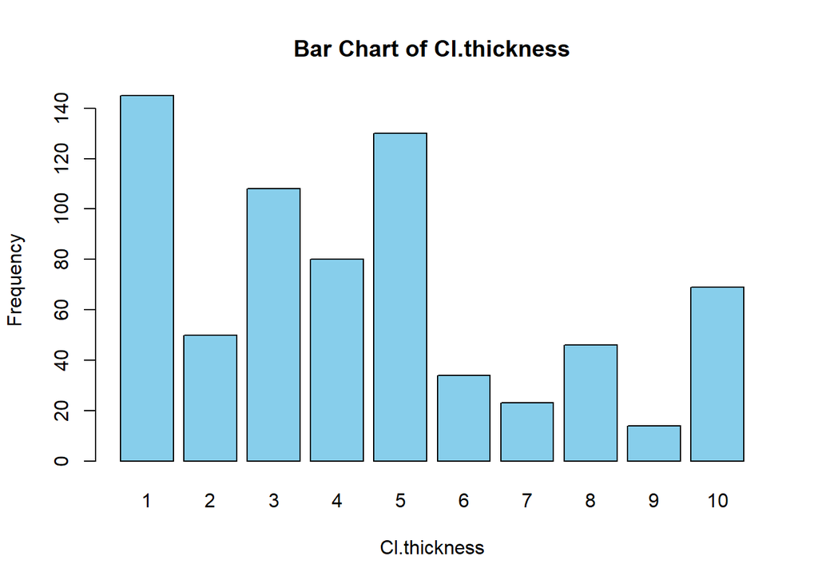

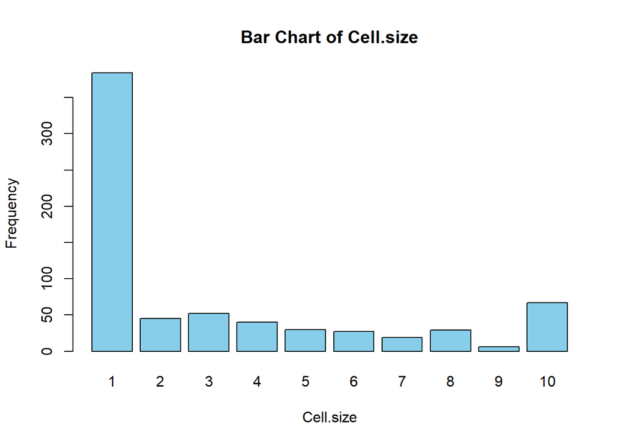

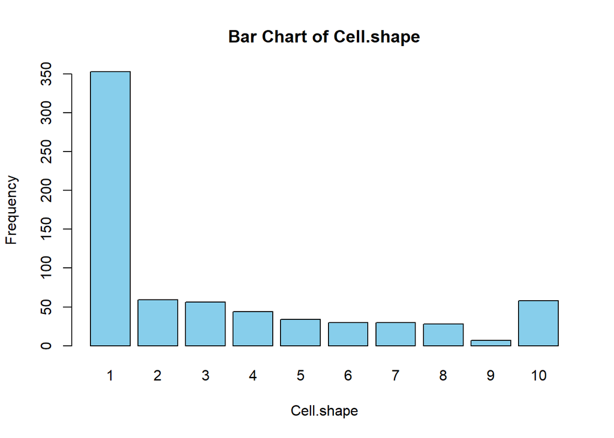

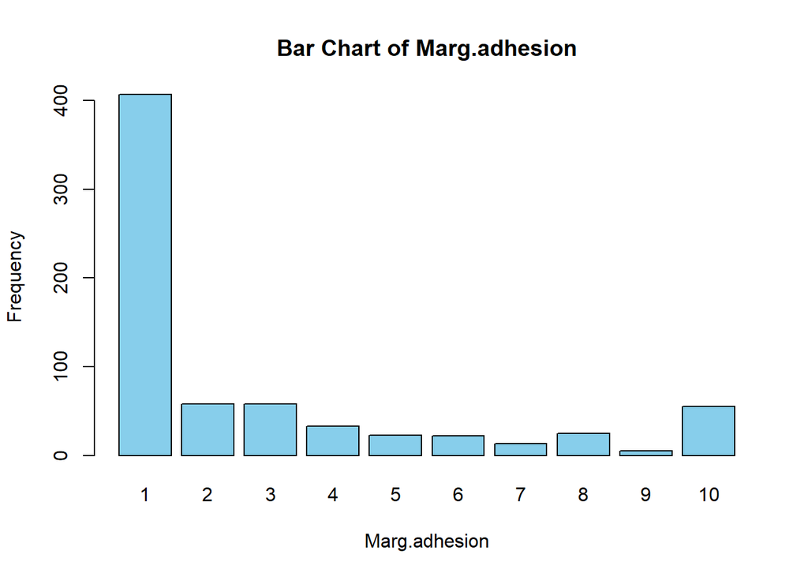

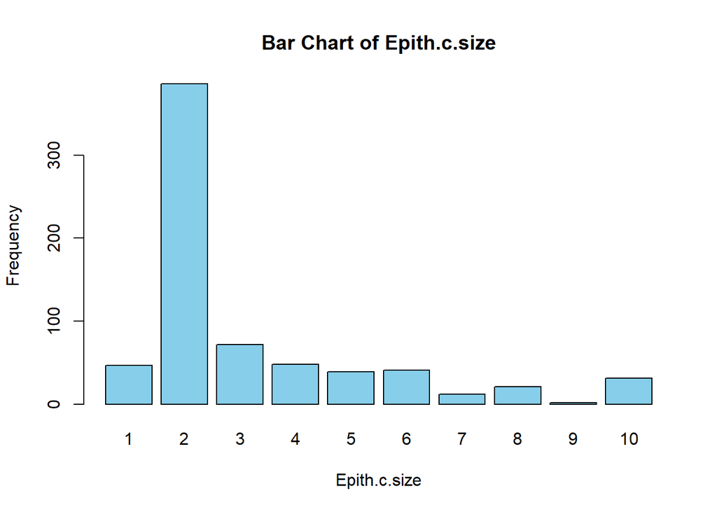

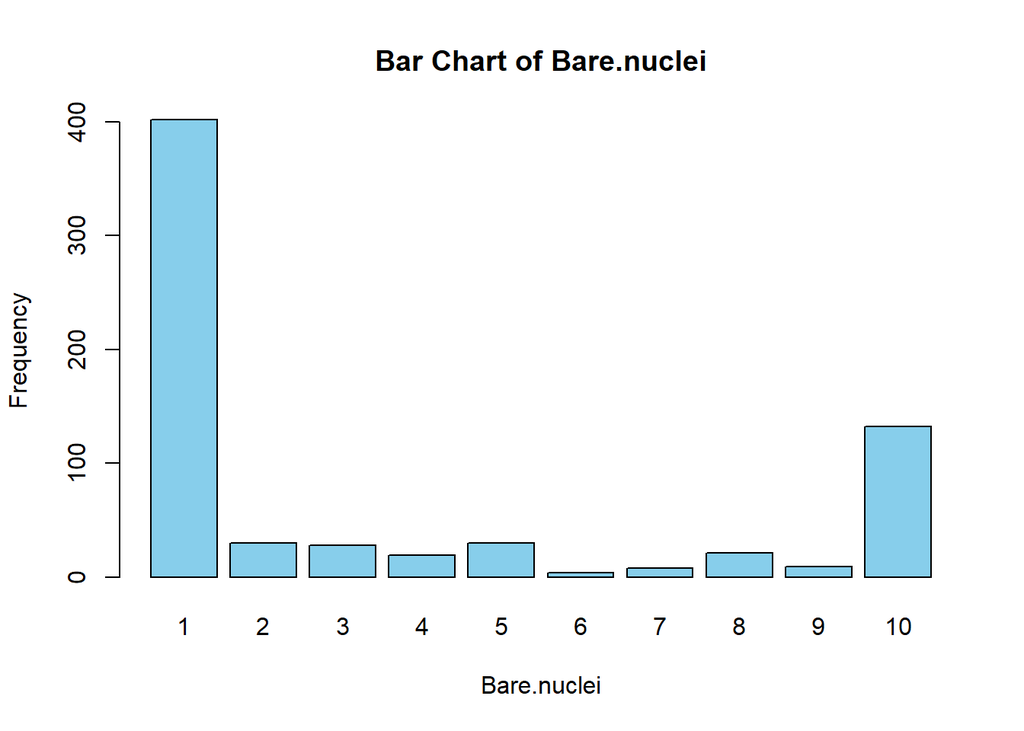

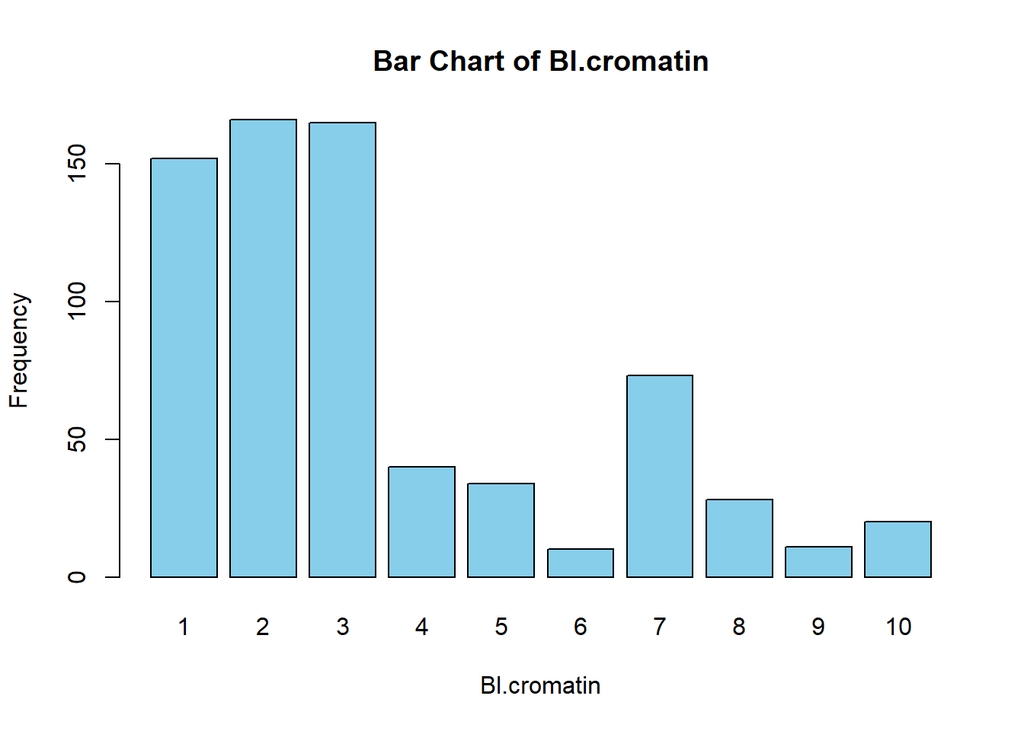

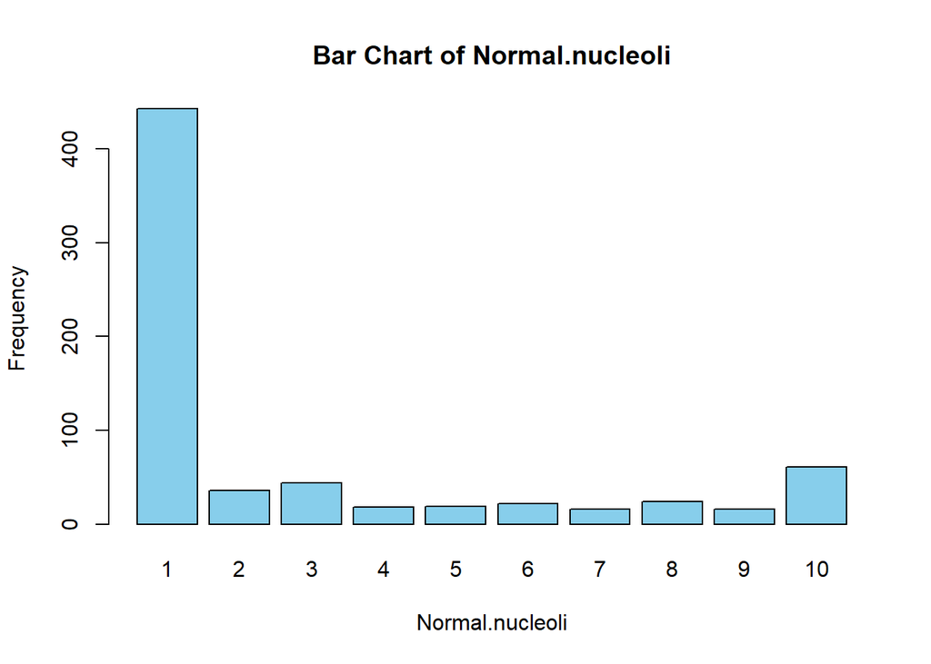

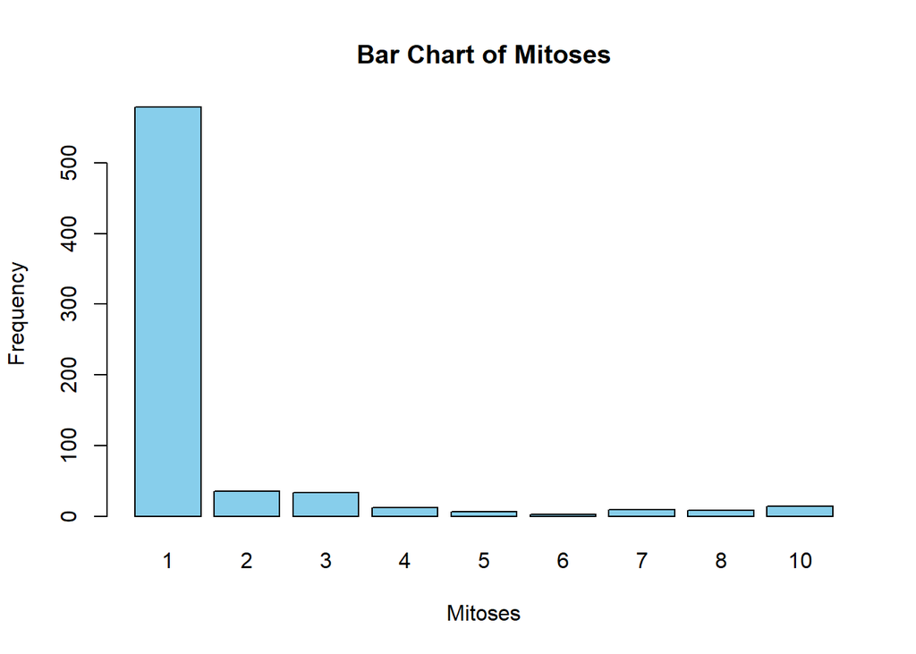

```r
# Loop over each variable in bc except 'Class'
for (var in names(bc)[names(bc) != "Class"]) {
  # Create a table of counts for the current variable
  counts <- table(bc[[var]])

  # Plot bar chart
  barplot(counts,
          main = paste("Bar Chart of", var),
          xlab = var,
          ylab = "Frequency",
          col = "skyblue",
          border = "black")
}
```

### Missing value check

```r
# Count missing values in each column
colSums(is.na(bc))
```

```
##    Cl.thickness       Cell.size      Cell.shape   Marg.adhesion    Epith.c.size
##               0               0               0               0               0
##     Bare.nuclei     Bl.cromatin Normal.nucleoli         Mitoses           Class
##              16               0               0               0               0
```

Only the variable Bare.nuclei has missing values so imputation done by mean

```r
bc$Bare.nuclei[is.na(bc$Bare.nuclei)]<-mean(bc$Bare.nuclei,na.rm=TRUE)
```

## Split The Dataset

```r
# Set seed and split
set.seed(123)
n <- nrow(bc)
train_indices <- sample(seq_len(n), size = 0.7 * n)
train_data <- bc[train_indices, ]
test_data  <- bc[-train_indices, ]

# Separate features and target
X_train <- train_data[, setdiff(names(train_data), "Class")]
y_train <- train_data$Class

X_test <- test_data[, setdiff(names(test_data), "Class")]
y_test <- test_data$Class
```

## Standardize features

```r
# Standardize features
X_train_scaled <- as.data.frame(scale(X_train))
X_test_scaled <- as.data.frame(scale(X_test,
                                     center = attr(scale(X_train), "scaled:center"),
                                     scale  = attr(scale(X_train), "scaled:scale")))

# Recombine with Class
train_data_std <- cbind(X_train_scaled, Class = y_train)
test_data_std  <- cbind(X_test_scaled,  Class = y_test)
```

## Linear Discriminant Analysis (LDA):

```r
lda_model <- lda(Class ~ ., data = train_data_std)
lda_model
```

```
## Call:
## lda(Class ~ ., data = train_data_std)
##
## Prior probabilities of groups:
##    benign malignant
## 0.6298569 0.3701431
##
## Group means:
##           Cl.thickness  Cell.size Cell.shape Marg.adhesion Epith.c.size
## benign      -0.5525424 -0.6347628 -0.6317555    -0.5542713   -0.5263338
## malignant    0.9402379  1.0801489  1.0750315     0.9431798    0.8956398
##           Bare.nuclei Bl.cromatin Normal.nucleoli    Mitoses
## benign     -0.6260617  -0.5841316      -0.5394302 -0.3397430
## malignant   1.0653426   0.9939919       0.9179254  0.5781262
##
## Coefficients of linear discriminants:
##                        LD1
## Cl.thickness    0.52128253
## Cell.size       0.57638526
## Cell.shape      0.26500144
## Marg.adhesion   0.07572540
## Epith.c.size    0.05400856
## Bare.nuclei     0.96415912
## Bl.cromatin     0.25928299
## Normal.nucleoli 0.23211124
## Mitoses         0.01926883
```

```r
lda_pred <- predict(lda_model, test_data_std)$class

lda_cm <- table(Predicted = lda_pred, Actual = test_data_std$Class)
print(lda_cm)
```

```
##            Actual
## Predicted   benign malignant
##   benign       145         4
##   malignant      5        56
```

## Quadratic Discriminant Analysis (QDA):

```r
qda_model <- qda(Class ~ ., data = train_data_std)
qda_model
```

```
## Call:
## qda(Class ~ ., data = train_data_std)
##
## Prior probabilities of groups:
##    benign malignant
## 0.6298569 0.3701431
##
## Group means:
##           Cl.thickness  Cell.size Cell.shape Marg.adhesion Epith.c.size
## benign      -0.5525424 -0.6347628 -0.6317555    -0.5542713   -0.5263338
## malignant    0.9402379  1.0801489  1.0750315     0.9431798    0.8956398
##           Bare.nuclei Bl.cromatin Normal.nucleoli    Mitoses
## benign     -0.6260617  -0.5841316      -0.5394302 -0.3397430
## malignant   1.0653426   0.9939919       0.9179254  0.5781262
```

```r
qda_pred <- predict(qda_model, test_data_std)$class

qda_cm <- table(Predicted = qda_pred, Actual = test_data_std$Class)
print(qda_cm)
```

```
##            Actual
## Predicted   benign malignant
##   benign       137         1
##   malignant     13        59
```

## Logistic Regression

```r
log_model <- glm(Class ~ ., data = train_data_std, family = binomial)
log_model
```

```
##
## Call:  glm(formula = Class ~ ., family = binomial, data = train_data_std)
##
## Coefficients:
##     (Intercept)     Cl.thickness        Cell.size       Cell.shape
##         -0.5130           1.4323           1.1065           1.6949
##   Marg.adhesion     Epith.c.size      Bare.nuclei      Bl.cromatin
##          0.2460          -0.2190           1.8639           0.6592
## Normal.nucleoli          Mitoses
##          0.1010           0.5895
##
## Degrees of Freedom: 488 Total (i.e. Null);  479 Residual
## Null Deviance:       644.5
## Residual Deviance: 72.55     AIC: 92.55
```

```r
log_probs <- predict(log_model, newdata = test_data_std, type = "response")
# Convert probs to class labels (adjust threshold as needed)
log_pred <- ifelse(log_probs >= 0.5, levels(y_train)[2], levels(y_train)[1])
log_pred <- factor(log_pred, levels = levels(y_train))
log_cm <- table(Predicted = log_pred, Actual = test_data_std$Class)
print(log_cm)
```

```
##            Actual
## Predicted   benign malignant
##   benign       144         2
##   malignant      6        58
```

### Defining a function for model evaluation

```r
evaluate_model <- function(predicted, actual) {
  cm <- table(Predicted = predicted, Actual = actual)

  accuracy <- sum(diag(cm)) / sum(cm)
  precision <- diag(cm) / rowSums(cm)
  recall <- diag(cm) / colSums(cm)
  f1 <- 2 * (precision * recall) / (precision + recall)


  # Macro-averaged metrics: average across classes
  macro_precision <- mean(precision)
  macro_recall <- mean(recall)
  macro_f1 <- mean(f1)

  # Return as named vector or data frame
  return(c(
    Accuracy = round(accuracy, 4),
    Precision = round(macro_precision, 4),
    Recall = round(macro_recall, 4),
    F1_Score = round(macro_f1, 4)
  ))
}
```

# Model Evaluation

```r
lda_results <- evaluate_model(lda_pred, test_data_std$Class)
lda_results
```

```
##  Accuracy Precision    Recall  F1_Score
##    0.9571    0.9456    0.9500    0.9478
```

```r
qda_results <- evaluate_model(qda_pred, test_data_std$Class)
qda_results
```

```
##  Accuracy Precision    Recall  F1_Score
##    0.9333    0.9061    0.9483    0.9227
```

```r
log_results <- evaluate_model(log_pred, test_data_std$Class)
log_results
```

```
##  Accuracy Precision    Recall  F1_Score
##    0.9619    0.9463    0.9633    0.9542
```

# Model Comparison

```r
comparison_table <- rbind(
  LDA = lda_results,
  QDA = qda_results,
  Logistic = log_results
)

print(comparison_table)
```

```
##          Accuracy Precision Recall F1_Score
## LDA        0.9571    0.9456 0.9500   0.9478
## QDA        0.9333    0.9061 0.9483   0.9227
## Logistic   0.9619    0.9463 0.9633   0.9542
```

Logistic Regression achieves the highest accuracy (0.9619), followed by LDA (0.9571) and QDA (0.9333). In terms of precision, Logistic Regression again leads (0.9463), indicating it produces fewer false positives compared to LDA (0.9456) and QDA (0.9061). Recall is highest for Logistic Regression (0.9633), meaning it correctly identifies most positive cases, while QDA also has a high recall (0.9483) but lower precision. The F1-Score, which balances precision and recall, is slightly higher for Logistic Regression (0.9542) compared to LDA (0.9478) and QDA (0.9227).

#### Best Performing Algorithm

Logistic Regression demonstrates the best overall balance between precision and recall, resulting in the highest F1-score and making it the most reliable model for overall classification performance. LDA performs similarly to Logistic Regression, with only slightly lower recall and F1-score, and remains a strong option when the normality assumption approximately holds. QDA shows very high recall, indicating it effectively identifies positive cases, but its lower precision leads to more false positives. Its assumption of different covariance structures for each class may not perfectly match this dataset, slightly reducing its overall accuracy.